# “Titanic EDA”

### MULTIVARIABLE PART E – CABIN DECK VS. PCLASS

### This facet grid is to establish which Cabin_decks were associated with which Pclass for purposes of discussion/analysis

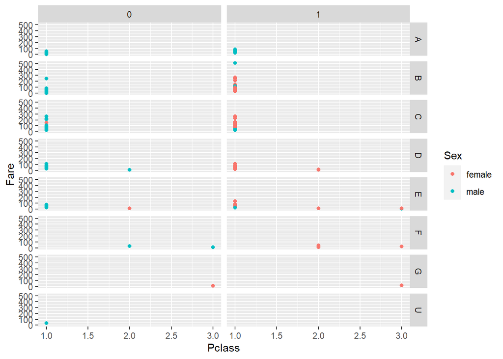

```r
library(tidyverse)
library(readxl)
library(stringr)
library(dplyr)
library(ggplot2)
titanic <- read_xlsx('titanic_partial.xlsx')
titanic$Sex <- as.character(titanic$Sex)
titanic$Pclass <- as.character(titanic$Pclass)
titanic$Survived <- as.character(titanic$Survived)

ggplot(data = titanic_no_cabin_na) +
  geom_point(mapping= aes(x=Pclass, y= Fare, color = Sex)) +
  facet_grid(Cabin_deck ~ Survived)
```

## Each section is summarized within that section for that table or graph. But to give an overall summary of the results, the primary factor that dictated who survived was Gender/Sex, with women surviving much more than men. After that the second factor was Pclass, with Pclass 1 surviving better than Pclass 2 and much better than Pclass 3. Within gender, trends were explored to see if young/unmarried ladies (Miss) were saved more than married women (Mrs), with somemixed results. The same question was asked about young/unmarried men (Master) vs. married men (Mr). None of the pastors (Rev) survived, and only 3 of 7 doctors (Dr) survived (one because she was female, plus half the Pclass 1 male doctors), so that doesn’t say much about the status of Reverends and Doctors on the ship.

## For the factor Age, it was true that older men/women were more often in Pclass 1 and younger men/women were more often in Pclass 3, age was shown not to be a significant factor by a box plot chart, which showed the survivors to have a slightly younger average age (23) than the non-survivors (25), but the plots were very similar, so that isn’t a primary factor.

## Disclaimer: Any analysis of Cabin_deck is limited, because only 204 of 891 entries had a Cabin listed. The location of the deck (the letter before the number on the Cabin) was summarized as a 15th column, Cabin_deck. There were some differences seen in the number of people saved from various decks, so some might have been further away from the damage to the ship, or closer to the lifeboats. The Cabin_decks that survived the best were B,D and E, with poorer results from Cabin_decks A, C and G, and no survivors in the small U category. Looking at a Titanic website, the decks were arranged with A at the top, then B,C,D,E,F,G going down towards the hull of the ship. Each deck extended the length of the ship. Pclass 1 was in Decks A,B,C,D,E, and Pclass 2 was in Decks D,E,F. Pclass 3 was held in E,F,G and those decks flooded first. Also, Pclass 3 passengers were required to be kept separate from Pclass 1 and 2 passengers to prevent the spread of disease, and they even were to disembark at a different location at their destination. So as the ship started sinking, staff closed doors, denying Pclass 3 passengers a route to the ship’s surface, which explains why even many women in Pclass 3 died.

## The Embarked location (C,Q or S) shows 3x the number of people embarked at location S, but it had the poorest survival rate. Location C had the best survival, but a closer look at embarkation location as a function of Pclass shows that probably the reason location C had the best survival was that it had the largest percentage of Pclass 1 passengers. It was surprising though that location Q was nearly all Pclass 3 passengers but it had the 2nd best survival rate. That is probably due to location S having > 600 passengers, compared to locations C and Q having less than 200 and 100, respectively. It just isn’t easy to save all 600 of the location S people.